# Risk Factor Analysis

## Outcome Variable

**Outcome Variable:** y_rate_haz

## Predictor Variables

**Intervention Variable:** nhh

**Adjustment Set:**

- arm
- W_mage
- meducyrs
- feducyrs
- W_mhtcm
- W_mwtkg
- W_mbmi
- W_nrooms
- trth2o
- cleanck
- impfloor
- impsan
- safeh20
- delta_W_mage
- delta_meducyrs
- delta_feducyrs
- delta_W_mhtcm
- delta_W_mwtkg
- delta_W_mbmi
- delta_W_nrooms
- delta_trth2o
- delta_cleanck
- delta_impfloor
- delta_impsan
- delta_safeh20

## Stratifying Variables

The analysis was stratified on these variable(s):

- agecat
- studyid
- country

## Data Summary

| agecat | studyid | country | nhh | n_cell | n | outcome_variable |
| --- | --- | --- | --- | --- | --- | --- |
| 0-3 months | ki1000108-IRC | INDIA | 3 or less | 53 | 377 | y_rate_haz |
| 0-3 months | ki1000108-IRC | INDIA | 4-5 | 146 | 377 | y_rate_haz |
| 0-3 months | ki1000108-IRC | INDIA | 6-7 | 99 | 377 | y_rate_haz |
| 0-3 months | ki1000108-IRC | INDIA | 8+ | 79 | 377 | y_rate_haz |
| 0-3 months | ki1017093-NIH-Birth | BANGLADESH | 3 or less | 101 | 566 | y_rate_haz |
| 0-3 months | ki1017093-NIH-Birth | BANGLADESH | 4-5 | 239 | 566 | y_rate_haz |
| 0-3 months | ki1017093-NIH-Birth | BANGLADESH | 6-7 | 132 | 566 | y_rate_haz |
| 0-3 months | ki1017093-NIH-Birth | BANGLADESH | 8+ | 94 | 566 | y_rate_haz |
| 0-3 months | ki1017093b-PROVIDE | BANGLADESH | 3 or less | 123 | 640 | y_rate_haz |
| 0-3 months | ki1017093b-PROVIDE | BANGLADESH | 4-5 | 296 | 640 | y_rate_haz |
| 0-3 months | ki1017093b-PROVIDE | BANGLADESH | 6-7 | 136 | 640 | y_rate_haz |
| 0-3 months | ki1017093b-PROVIDE | BANGLADESH | 8+ | 85 | 640 | y_rate_haz |
| 0-3 months | ki1017093c-NIH-Crypto | BANGLADESH | 3 or less | 108 | 721 | y_rate_haz |
| 0-3 months | ki1017093c-NIH-Crypto | BANGLADESH | 4-5 | 324 | 721 | y_rate_haz |
| 0-3 months | ki1017093c-NIH-Crypto | BANGLADESH | 6-7 | 169 | 721 | y_rate_haz |
| 0-3 months | ki1017093c-NIH-Crypto | BANGLADESH | 8+ | 120 | 721 | y_rate_haz |
| 3-6 months | ki1000108-IRC | INDIA | 3 or less | 57 | 397 | y_rate_haz |
| 3-6 months | ki1000108-IRC | INDIA | 4-5 | 154 | 397 | y_rate_haz |
| 3-6 months | ki1000108-IRC | INDIA | 6-7 | 103 | 397 | y_rate_haz |
| 3-6 months | ki1000108-IRC | INDIA | 8+ | 83 | 397 | y_rate_haz |
| 3-6 months | ki1017093-NIH-Birth | BANGLADESH | 3 or less | 89 | 523 | y_rate_haz |
| 3-6 months | ki1017093-NIH-Birth | BANGLADESH | 4-5 | 223 | 523 | y_rate_haz |
| 3-6 months | ki1017093-NIH-Birth | BANGLADESH | 6-7 | 126 | 523 | y_rate_haz |
| 3-6 months | ki1017093-NIH-Birth | BANGLADESH | 8+ | 85 | 523 | y_rate_haz |
| 3-6 months | ki1017093b-PROVIDE | BANGLADESH | 3 or less | 104 | 598 | y_rate_haz |
| 3-6 months | ki1017093b-PROVIDE | BANGLADESH | 4-5 | 285 | 598 | y_rate_haz |
| 3-6 months | ki1017093b-PROVIDE | BANGLADESH | 6-7 | 129 | 598 | y_rate_haz |
| 3-6 months | ki1017093b-PROVIDE | BANGLADESH | 8+ | 80 | 598 | y_rate_haz |
| 3-6 months | ki1017093c-NIH-Crypto | BANGLADESH | 3 or less | 101 | 695 | y_rate_haz |
| 3-6 months | ki1017093c-NIH-Crypto | BANGLADESH | 4-5 | 316 | 695 | y_rate_haz |

[output cut: 138 more lines]

The following strata were considered:

- agecat: 0-3 months, studyid: ki1000108-IRC, country: INDIA
- agecat: 0-3 months, studyid: ki1017093-NIH-Birth, country: BANGLADESH
- agecat: 0-3 months, studyid: ki1017093b-PROVIDE, country: BANGLADESH
- agecat: 0-3 months, studyid: ki1017093c-NIH-Crypto, country: BANGLADESH
- agecat: 12-15 months, studyid: ki1000108-IRC, country: INDIA
- agecat: 12-15 months, studyid: ki1000304b-SAS-FoodSuppl, country: INDIA
- agecat: 12-15 months, studyid: ki1017093-NIH-Birth, country: BANGLADESH
- agecat: 12-15 months, studyid: ki1017093b-PROVIDE, country: BANGLADESH
- agecat: 12-15 months, studyid: ki1017093c-NIH-Crypto, country: BANGLADESH
- agecat: 12-15 months, studyid: ki1148112-LCNI-5, country: MALAWI
- agecat: 15-18 months, studyid: ki1000108-IRC, country: INDIA
- agecat: 15-18 months, studyid: ki1000304b-SAS-FoodSuppl, country: INDIA
- agecat: 15-18 months, studyid: ki1017093-NIH-Birth, country: BANGLADESH
- agecat: 15-18 months, studyid: ki1017093b-PROVIDE, country: BANGLADESH
- agecat: 15-18 months, studyid: ki1017093c-NIH-Crypto, country: BANGLADESH
- agecat: 15-18 months, studyid: ki1148112-LCNI-5, country: MALAWI
- agecat: 18-21 months, studyid: ki1000108-IRC, country: INDIA
- agecat: 18-21 months, studyid: ki1017093-NIH-Birth, country: BANGLADESH
- agecat: 18-21 months, studyid: ki1017093b-PROVIDE, country: BANGLADESH
- agecat: 18-21 months, studyid: ki1017093c-NIH-Crypto, country: BANGLADESH
- agecat: 18-21 months, studyid: ki1148112-LCNI-5, country: MALAWI
- agecat: 21-24 months, studyid: ki1000108-IRC, country: INDIA
- agecat: 21-24 months, studyid: ki1017093-NIH-Birth, country: BANGLADESH
- agecat: 21-24 months, studyid: ki1017093b-PROVIDE, country: BANGLADESH
- agecat: 21-24 months, studyid: ki1017093c-NIH-Crypto, country: BANGLADESH
- agecat: 21-24 months, studyid: ki1148112-LCNI-5, country: MALAWI
- agecat: 3-6 months, studyid: ki1000108-IRC, country: INDIA
- agecat: 3-6 months, studyid: ki1017093-NIH-Birth, country: BANGLADESH
- agecat: 3-6 months, studyid: ki1017093b-PROVIDE, country: BANGLADESH
- agecat: 3-6 months, studyid: ki1017093c-NIH-Crypto, country: BANGLADESH
- agecat: 6-9 months, studyid: ki1000108-IRC, country: INDIA
- agecat: 6-9 months, studyid: ki1000304b-SAS-FoodSuppl, country: INDIA
- agecat: 6-9 months, studyid: ki1017093-NIH-Birth, country: BANGLADESH
- agecat: 6-9 months, studyid: ki1017093b-PROVIDE, country: BANGLADESH
- agecat: 6-9 months, studyid: ki1017093c-NIH-Crypto, country: BANGLADESH
- agecat: 6-9 months, studyid: ki1148112-LCNI-5, country: MALAWI
- agecat: 9-12 months, studyid: ki1000108-IRC, country: INDIA
- agecat: 9-12 months, studyid: ki1000304b-SAS-FoodSuppl, country: INDIA
- agecat: 9-12 months, studyid: ki1017093-NIH-Birth, country: BANGLADESH
- agecat: 9-12 months, studyid: ki1017093b-PROVIDE, country: BANGLADESH
- agecat: 9-12 months, studyid: ki1017093c-NIH-Crypto, country: BANGLADESH
- agecat: 9-12 months, studyid: ki1148112-LCNI-5, country: MALAWI

## Methods Detail

We’re interested in the causal parameters $E[Y_a]$ for all values of $a \in \mathcal{A}$. These parameters represent the mean outcome if, possibly contrary to fact, we intervened to set all units to have $A=a$. Under the randomization and positivity assumptions, these are identified by the statistical parameters $\psi_a=E_W[E_{Y|A,W}(Y|A=a,W)]$. In addition, we’re interested in the mean of $Y$, $E[Y]$ under no intervention (the observed mean). We will estimate these parameters by using SuperLearner to fit the relevant likelihood factors – $E_{Y|A,W}(Y|A=a,W)$ and $p(A=a|W)$, and then updating our likelihood fit using a joint TMLE.

For unadjusted analyses ($W=\{\}$), initial likelihoods were estimated using Lrnr_glm to estimate the simple $E(Y|A)$ and Lrnr_mean to estimate $p(A)$. For adjusted analyses, a small library containing Lrnr_glmnet, Lrnr_xgboost, and Lrnr_mean was used.

Having estimated these parameters, we will then use the delta method to estimate relative risks and attributable risks relative to a prespecified baseline level of $A$.

# Results Detail

## Results Plots

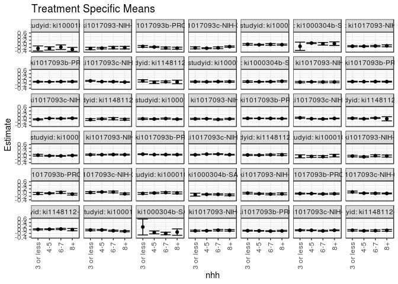

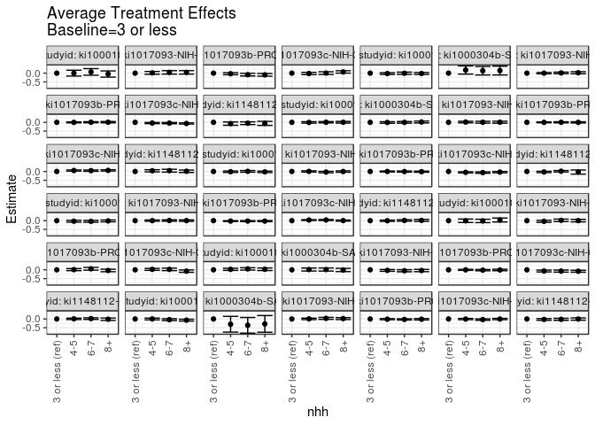

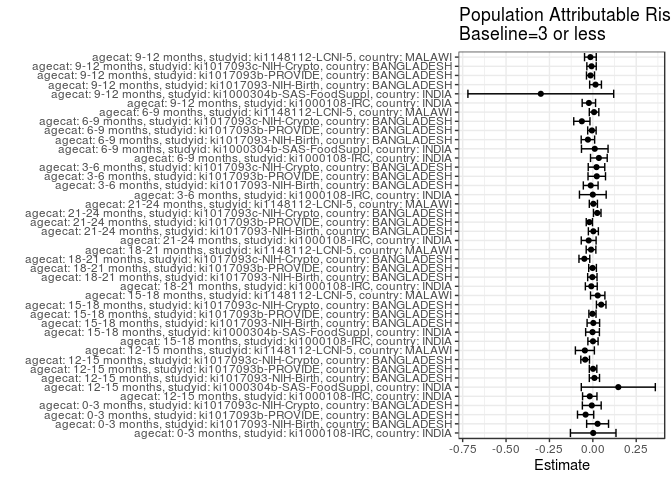

## Results Table

### Parameter: TSM

| agecat | studyid | country | intervention_level | baseline_level | estimate | ci_lower | ci_upper |
| --- | --- | --- | --- | --- | --- | --- | --- |
| 0-3 months | ki1000108-IRC | INDIA | 3 or less | NA | -0.2579288 | -0.3982345 | -0.1176232 |
| 0-3 months | ki1000108-IRC | INDIA | 4-5 | NA | -0.2565209 | -0.3477662 | -0.1652757 |
| 0-3 months | ki1000108-IRC | INDIA | 6-7 | NA | -0.1870830 | -0.3133049 | -0.0608611 |
| 0-3 months | ki1000108-IRC | INDIA | 8+ | NA | -0.3059247 | -0.4128335 | -0.1990158 |
| 0-3 months | ki1017093-NIH-Birth | BANGLADESH | 3 or less | NA | -0.2593974 | -0.3282433 | -0.1905515 |
| 0-3 months | ki1017093-NIH-Birth | BANGLADESH | 4-5 | NA | -0.2421136 | -0.2816920 | -0.2025351 |
| 0-3 months | ki1017093-NIH-Birth | BANGLADESH | 6-7 | NA | -0.2142169 | -0.2845006 | -0.1439331 |
| 0-3 months | ki1017093-NIH-Birth | BANGLADESH | 8+ | NA | -0.2140647 | -0.2849513 | -0.1431781 |
| 0-3 months | ki1017093b-PROVIDE | BANGLADESH | 3 or less | NA | -0.1464358 | -0.1963429 | -0.0965287 |
| 0-3 months | ki1017093b-PROVIDE | BANGLADESH | 4-5 | NA | -0.1773940 | -0.2068271 | -0.1479609 |
| 0-3 months | ki1017093b-PROVIDE | BANGLADESH | 6-7 | NA | -0.2316322 | -0.2873524 | -0.1759120 |
| 0-3 months | ki1017093b-PROVIDE | BANGLADESH | 8+ | NA | -0.2415619 | -0.2986999 | -0.1844240 |
| 0-3 months | ki1017093c-NIH-Crypto | BANGLADESH | 3 or less | NA | -0.2251408 | -0.2819698 | -0.1683117 |
| 0-3 months | ki1017093c-NIH-Crypto | BANGLADESH | 4-5 | NA | -0.2451427 | -0.2726370 | -0.2176485 |
| 0-3 months | ki1017093c-NIH-Crypto | BANGLADESH | 6-7 | NA | -0.2218682 | -0.2731228 | -0.1706137 |
| 0-3 months | ki1017093c-NIH-Crypto | BANGLADESH | 8+ | NA | -0.1550784 | -0.1908906 | -0.1192663 |
| 3-6 months | ki1000108-IRC | INDIA | 3 or less | NA | -0.0517820 | -0.1347837 | 0.0312197 |
| 3-6 months | ki1000108-IRC | INDIA | 4-5 | NA | -0.0585832 | -0.1117156 | -0.0054509 |
| 3-6 months | ki1000108-IRC | INDIA | 6-7 | NA | -0.0669538 | -0.1191440 | -0.0147637 |
| 3-6 months | ki1000108-IRC | INDIA | 8+ | NA | -0.0147752 | -0.0881206 | 0.0585703 |
| 3-6 months | ki1017093-NIH-Birth | BANGLADESH | 3 or less | NA | -0.0386295 | -0.0830841 | 0.0058250 |
| 3-6 months | ki1017093-NIH-Birth | BANGLADESH | 4-5 | NA | -0.0759127 | -0.1104810 | -0.0413444 |
| 3-6 months | ki1017093-NIH-Birth | BANGLADESH | 6-7 | NA | -0.0201830 | -0.0751082 | 0.0347422 |
| 3-6 months | ki1017093-NIH-Birth | BANGLADESH | 8+ | NA | -0.0368723 | -0.0946694 | 0.0209249 |
| 3-6 months | ki1017093b-PROVIDE | BANGLADESH | 3 or less | NA | -0.0496384 | -0.1036433 | 0.0043665 |
| 3-6 months | ki1017093b-PROVIDE | BANGLADESH | 4-5 | NA | -0.0388145 | -0.0644004 | -0.0132285 |
| 3-6 months | ki1017093b-PROVIDE | BANGLADESH | 6-7 | NA | 0.0082875 | -0.0473077 | 0.0638827 |
| 3-6 months | ki1017093b-PROVIDE | BANGLADESH | 8+ | NA | -0.0876652 | -0.1359581 | -0.0393723 |
| 3-6 months | ki1017093c-NIH-Crypto | BANGLADESH | 3 or less | NA | 0.0056566 | -0.0433035 | 0.0546168 |
| 3-6 months | ki1017093c-NIH-Crypto | BANGLADESH | 4-5 | NA | 0.0320666 | 0.0039298 | 0.0602034 |

[output cut: 138 more lines]

### Parameter: E(Y)

| agecat | studyid | country | intervention_level | baseline_level | estimate | ci_lower | ci_upper |
| --- | --- | --- | --- | --- | --- | --- | --- |
| 0-3 months | ki1000108-IRC | INDIA | NA | NA | -0.2558271 | -0.3111464 | -0.2005078 |
| 0-3 months | ki1017093-NIH-Birth | BANGLADESH | NA | NA | -0.2319865 | -0.2585900 | -0.2053830 |
| 0-3 months | ki1017093b-PROVIDE | BANGLADESH | NA | NA | -0.1880402 | -0.2054115 | -0.1706689 |
| 0-3 months | ki1017093c-NIH-Crypto | BANGLADESH | NA | NA | -0.2312607 | -0.2486732 | -0.2138483 |
| 3-6 months | ki1000108-IRC | INDIA | NA | NA | -0.0518918 | -0.0819849 | -0.0217987 |
| 3-6 months | ki1017093-NIH-Birth | BANGLADESH | NA | NA | -0.0509007 | -0.0730097 | -0.0287917 |
| 3-6 months | ki1017093b-PROVIDE | BANGLADESH | NA | NA | -0.0269625 | -0.0428628 | -0.0110622 |
| 3-6 months | ki1017093c-NIH-Crypto | BANGLADESH | NA | NA | 0.0267740 | 0.0099602 | 0.0435879 |
| 6-9 months | ki1000108-IRC | INDIA | NA | NA | -0.0162677 | -0.0378604 | 0.0053250 |
| 6-9 months | ki1000304b-SAS-FoodSuppl | INDIA | NA | NA | -0.1052304 | -0.1233192 | -0.0871417 |
| 6-9 months | ki1017093-NIH-Birth | BANGLADESH | NA | NA | -0.0595548 | -0.0774135 | -0.0416961 |
| 6-9 months | ki1017093b-PROVIDE | BANGLADESH | NA | NA | -0.0614264 | -0.0722690 | -0.0505838 |
| 6-9 months | ki1017093c-NIH-Crypto | BANGLADESH | NA | NA | -0.0313638 | -0.0441155 | -0.0186120 |
| 6-9 months | ki1148112-LCNI-5 | MALAWI | NA | NA | 0.0279334 | 0.0120046 | 0.0438622 |
| 9-12 months | ki1000108-IRC | INDIA | NA | NA | -0.0361313 | -0.0530672 | -0.0191954 |
| 9-12 months | ki1000304b-SAS-FoodSuppl | INDIA | NA | NA | -0.1462637 | -0.2015231 | -0.0910043 |
| 9-12 months | ki1017093-NIH-Birth | BANGLADESH | NA | NA | -0.0424748 | -0.0569242 | -0.0280255 |
| 9-12 months | ki1017093b-PROVIDE | BANGLADESH | NA | NA | -0.0630470 | -0.0740183 | -0.0520757 |
| 9-12 months | ki1017093c-NIH-Crypto | BANGLADESH | NA | NA | -0.0342995 | -0.0452397 | -0.0233593 |
| 9-12 months | ki1148112-LCNI-5 | MALAWI | NA | NA | -0.0433141 | -0.0626948 | -0.0239333 |
| 12-15 months | ki1000108-IRC | INDIA | NA | NA | -0.0454519 | -0.0622041 | -0.0286997 |
| 12-15 months | ki1000304b-SAS-FoodSuppl | INDIA | NA | NA | 0.0088746 | -0.0268397 | 0.0445889 |
| 12-15 months | ki1017093-NIH-Birth | BANGLADESH | NA | NA | -0.1259588 | -0.1428870 | -0.1090306 |
| 12-15 months | ki1017093b-PROVIDE | BANGLADESH | NA | NA | -0.0409107 | -0.0510053 | -0.0308161 |
| 12-15 months | ki1017093c-NIH-Crypto | BANGLADESH | NA | NA | -0.0383313 | -0.0478154 | -0.0288473 |
| 12-15 months | ki1148112-LCNI-5 | MALAWI | NA | NA | -0.0403575 | -0.0774359 | -0.0032790 |
| 15-18 months | ki1000108-IRC | INDIA | NA | NA | -0.0385167 | -0.0531981 | -0.0238352 |
| 15-18 months | ki1000304b-SAS-FoodSuppl | INDIA | NA | NA | -0.0369125 | -0.0500204 | -0.0238046 |
| 15-18 months | ki1017093-NIH-Birth | BANGLADESH | NA | NA | -0.0576906 | -0.0723785 | -0.0430027 |
| 15-18 months | ki1017093b-PROVIDE | BANGLADESH | NA | NA | -0.0376437 | -0.0463882 | -0.0288992 |
| 15-18 months | ki1017093c-NIH-Crypto | BANGLADESH | NA | NA | -0.0169074 | -0.0252557 | -0.0085590 |
| 15-18 months | ki1148112-LCNI-5 | MALAWI | NA | NA | -0.0464023 | -0.0722064 | -0.0205982 |
| 18-21 months | ki1000108-IRC | INDIA | NA | NA | -0.0400816 | -0.0533440 | -0.0268193 |
| 18-21 months | ki1017093-NIH-Birth | BANGLADESH | NA | NA | -0.0383890 | -0.0508204 | -0.0259576 |
| 18-21 months | ki1017093b-PROVIDE | BANGLADESH | NA | NA | -0.0109399 | -0.0190984 | -0.0027814 |
| 18-21 months | ki1017093c-NIH-Crypto | BANGLADESH | NA | NA | -0.0279687 | -0.0360019 | -0.0199355 |
| 18-21 months | ki1148112-LCNI-5 | MALAWI | NA | NA | -0.0147327 | -0.0309734 | 0.0015080 |
| 21-24 months | ki1000108-IRC | INDIA | NA | NA | -0.0139081 | -0.0274784 | -0.0003379 |
| 21-24 months | ki1017093-NIH-Birth | BANGLADESH | NA | NA | 0.0406915 | 0.0289394 | 0.0524435 |
| 21-24 months | ki1017093b-PROVIDE | BANGLADESH | NA | NA | 0.0462342 | 0.0375872 | 0.0548812 |
| 21-24 months | ki1017093c-NIH-Crypto | BANGLADESH | NA | NA | 0.0587621 | 0.0505315 | 0.0669927 |
| 21-24 months | ki1148112-LCNI-5 | MALAWI | NA | NA | 0.0258428 | 0.0105053 | 0.0411803 |

### Parameter: ATE

| agecat | studyid | country | intervention_level | baseline_level | estimate | ci_lower | ci_upper |
| --- | --- | --- | --- | --- | --- | --- | --- |
| 0-3 months | ki1000108-IRC | INDIA | 3 or less | 3 or less | 0.0000000 | 0.0000000 | 0.0000000 |
| 0-3 months | ki1000108-IRC | INDIA | 4-5 | 3 or less | 0.0014079 | -0.1661964 | 0.1690122 |
| 0-3 months | ki1000108-IRC | INDIA | 6-7 | 3 or less | 0.0708458 | -0.1179155 | 0.2596072 |
| 0-3 months | ki1000108-IRC | INDIA | 8+ | 3 or less | -0.0479959 | -0.2247808 | 0.1287890 |
| 0-3 months | ki1017093-NIH-Birth | BANGLADESH | 3 or less | 3 or less | 0.0000000 | 0.0000000 | 0.0000000 |
| 0-3 months | ki1017093-NIH-Birth | BANGLADESH | 4-5 | 3 or less | 0.0172838 | -0.0625076 | 0.0970753 |
| 0-3 months | ki1017093-NIH-Birth | BANGLADESH | 6-7 | 3 or less | 0.0451805 | -0.0531486 | 0.1435096 |
| 0-3 months | ki1017093-NIH-Birth | BANGLADESH | 8+ | 3 or less | 0.0453327 | -0.0537528 | 0.1444183 |
| 0-3 months | ki1017093b-PROVIDE | BANGLADESH | 3 or less | 3 or less | 0.0000000 | 0.0000000 | 0.0000000 |
| 0-3 months | ki1017093b-PROVIDE | BANGLADESH | 4-5 | 3 or less | -0.0309582 | -0.0890298 | 0.0271135 |
| 0-3 months | ki1017093b-PROVIDE | BANGLADESH | 6-7 | 3 or less | -0.0851964 | -0.1599283 | -0.0104645 |
| 0-3 months | ki1017093b-PROVIDE | BANGLADESH | 8+ | 3 or less | -0.0951261 | -0.1709567 | -0.0192955 |
| 0-3 months | ki1017093c-NIH-Crypto | BANGLADESH | 3 or less | 3 or less | 0.0000000 | 0.0000000 | 0.0000000 |
| 0-3 months | ki1017093c-NIH-Crypto | BANGLADESH | 4-5 | 3 or less | -0.0200019 | -0.0832956 | 0.0432917 |
| 0-3 months | ki1017093c-NIH-Crypto | BANGLADESH | 6-7 | 3 or less | 0.0032725 | -0.0735406 | 0.0800857 |
| 0-3 months | ki1017093c-NIH-Crypto | BANGLADESH | 8+ | 3 or less | 0.0700623 | 0.0025999 | 0.1375248 |
| 3-6 months | ki1000108-IRC | INDIA | 3 or less | 3 or less | 0.0000000 | 0.0000000 | 0.0000000 |
| 3-6 months | ki1000108-IRC | INDIA | 4-5 | 3 or less | -0.0068012 | -0.1054923 | 0.0918898 |
| 3-6 months | ki1000108-IRC | INDIA | 6-7 | 3 or less | -0.0151718 | -0.1129219 | 0.0825783 |
| 3-6 months | ki1000108-IRC | INDIA | 8+ | 3 or less | 0.0370068 | -0.0743816 | 0.1483953 |
| 3-6 months | ki1017093-NIH-Birth | BANGLADESH | 3 or less | 3 or less | 0.0000000 | 0.0000000 | 0.0000000 |
| 3-6 months | ki1017093-NIH-Birth | BANGLADESH | 4-5 | 3 or less | -0.0372831 | -0.0935853 | 0.0190190 |
| 3-6 months | ki1017093-NIH-Birth | BANGLADESH | 6-7 | 3 or less | 0.0184466 | -0.0522061 | 0.0890992 |
| 3-6 months | ki1017093-NIH-Birth | BANGLADESH | 8+ | 3 or less | 0.0017573 | -0.0711468 | 0.0746613 |
| 3-6 months | ki1017093b-PROVIDE | BANGLADESH | 3 or less | 3 or less | 0.0000000 | 0.0000000 | 0.0000000 |
| 3-6 months | ki1017093b-PROVIDE | BANGLADESH | 4-5 | 3 or less | 0.0108240 | -0.0490390 | 0.0706870 |
| 3-6 months | ki1017093b-PROVIDE | BANGLADESH | 6-7 | 3 or less | 0.0579260 | -0.0195804 | 0.1354323 |
| 3-6 months | ki1017093b-PROVIDE | BANGLADESH | 8+ | 3 or less | -0.0380268 | -0.1104364 | 0.0343828 |
| 3-6 months | ki1017093c-NIH-Crypto | BANGLADESH | 3 or less | 3 or less | 0.0000000 | 0.0000000 | 0.0000000 |
| 3-6 months | ki1017093c-NIH-Crypto | BANGLADESH | 4-5 | 3 or less | 0.0264099 | -0.0303622 | 0.0831821 |

[output cut: 138 more lines]

### Parameter: PAR

| agecat | studyid | country | intervention_level | baseline_level | estimate | ci_lower | ci_upper |
| --- | --- | --- | --- | --- | --- | --- | --- |
| 0-3 months | ki1000108-IRC | INDIA | 3 or less | NA | 0.0021017 | -0.1292032 | 0.1334066 |
| 0-3 months | ki1017093-NIH-Birth | BANGLADESH | 3 or less | NA | 0.0274109 | -0.0356794 | 0.0905012 |
| 0-3 months | ki1017093b-PROVIDE | BANGLADESH | 3 or less | NA | -0.0416044 | -0.0883430 | 0.0051342 |
| 0-3 months | ki1017093c-NIH-Crypto | BANGLADESH | 3 or less | NA | -0.0061200 | -0.0603208 | 0.0480808 |
| 3-6 months | ki1000108-IRC | INDIA | 3 or less | NA | -0.0001098 | -0.0770845 | 0.0768649 |
| 3-6 months | ki1017093-NIH-Birth | BANGLADESH | 3 or less | NA | -0.0122711 | -0.0547778 | 0.0302355 |
| 3-6 months | ki1017093b-PROVIDE | BANGLADESH | 3 or less | NA | 0.0226759 | -0.0277061 | 0.0730580 |
| 3-6 months | ki1017093c-NIH-Crypto | BANGLADESH | 3 or less | NA | 0.0211174 | -0.0265095 | 0.0687443 |
| 6-9 months | ki1000108-IRC | INDIA | 3 or less | NA | 0.0347384 | -0.0133333 | 0.0828102 |
| 6-9 months | ki1000304b-SAS-FoodSuppl | INDIA | 3 or less | NA | 0.0111497 | -0.0654059 | 0.0877053 |
| 6-9 months | ki1017093-NIH-Birth | BANGLADESH | 3 or less | NA | -0.0282811 | -0.0669992 | 0.0104371 |
| 6-9 months | ki1017093b-PROVIDE | BANGLADESH | 3 or less | NA | -0.0053234 | -0.0295709 | 0.0189242 |
| 6-9 months | ki1017093c-NIH-Crypto | BANGLADESH | 3 or less | NA | -0.0633003 | -0.1099892 | -0.0166114 |
| 6-9 months | ki1148112-LCNI-5 | MALAWI | 3 or less | NA | 0.0070853 | -0.0203740 | 0.0345446 |
| 9-12 months | ki1000108-IRC | INDIA | 3 or less | NA | -0.0228368 | -0.0614223 | 0.0157487 |
| 9-12 months | ki1000304b-SAS-FoodSuppl | INDIA | 3 or less | NA | -0.2997895 | -0.7198012 | 0.1202223 |
| 9-12 months | ki1017093-NIH-Birth | BANGLADESH | 3 or less | NA | 0.0156084 | -0.0183120 | 0.0495287 |
| 9-12 months | ki1017093b-PROVIDE | BANGLADESH | 3 or less | NA | -0.0134057 | -0.0365922 | 0.0097808 |
| 9-12 months | ki1017093c-NIH-Crypto | BANGLADESH | 3 or less | NA | -0.0074611 | -0.0344741 | 0.0195519 |
| 9-12 months | ki1148112-LCNI-5 | MALAWI | 3 or less | NA | -0.0140303 | -0.0477865 | 0.0197259 |
| 12-15 months | ki1000108-IRC | INDIA | 3 or less | NA | -0.0176992 | -0.0591660 | 0.0237676 |
| 12-15 months | ki1000304b-SAS-FoodSuppl | INDIA | 3 or less | NA | 0.1467723 | -0.0665093 | 0.3600540 |
| 12-15 months | ki1017093-NIH-Birth | BANGLADESH | 3 or less | NA | 0.0091101 | -0.0203318 | 0.0385520 |
| 12-15 months | ki1017093b-PROVIDE | BANGLADESH | 3 or less | NA | 0.0013797 | -0.0202453 | 0.0230047 |
| 12-15 months | ki1017093c-NIH-Crypto | BANGLADESH | 3 or less | NA | -0.0442099 | -0.0691718 | -0.0192480 |
| 12-15 months | ki1148112-LCNI-5 | MALAWI | 3 or less | NA | -0.0458204 | -0.1005289 | 0.0088882 |
| 15-18 months | ki1000108-IRC | INDIA | 3 or less | NA | 0.0008579 | -0.0285659 | 0.0302817 |
| 15-18 months | ki1000304b-SAS-FoodSuppl | INDIA | 3 or less | NA | -0.0017234 | -0.0413680 | 0.0379213 |
| 15-18 months | ki1017093-NIH-Birth | BANGLADESH | 3 or less | NA | 0.0029487 | -0.0331231 | 0.0390204 |
| 15-18 months | ki1017093b-PROVIDE | BANGLADESH | 3 or less | NA | -0.0022025 | -0.0227624 | 0.0183575 |
| 15-18 months | ki1017093c-NIH-Crypto | BANGLADESH | 3 or less | NA | 0.0482473 | 0.0207291 | 0.0757654 |
| 15-18 months | ki1148112-LCNI-5 | MALAWI | 3 or less | NA | 0.0281119 | -0.0132476 | 0.0694715 |
| 18-21 months | ki1000108-IRC | INDIA | 3 or less | NA | -0.0088722 | -0.0430631 | 0.0253188 |
| 18-21 months | ki1017093-NIH-Birth | BANGLADESH | 3 or less | NA | -0.0027819 | -0.0297198 | 0.0241560 |
| 18-21 months | ki1017093b-PROVIDE | BANGLADESH | 3 or less | NA | -0.0016128 | -0.0237458 | 0.0205202 |
| 18-21 months | ki1017093c-NIH-Crypto | BANGLADESH | 3 or less | NA | -0.0488416 | -0.0799181 | -0.0177651 |
| 18-21 months | ki1148112-LCNI-5 | MALAWI | 3 or less | NA | -0.0104149 | -0.0382597 | 0.0174299 |
| 21-24 months | ki1000108-IRC | INDIA | 3 or less | NA | -0.0239413 | -0.0666923 | 0.0188096 |
| 21-24 months | ki1017093-NIH-Birth | BANGLADESH | 3 or less | NA | 0.0030751 | -0.0257277 | 0.0318780 |
| 21-24 months | ki1017093b-PROVIDE | BANGLADESH | 3 or less | NA | -0.0199577 | -0.0379984 | -0.0019170 |
| 21-24 months | ki1017093c-NIH-Crypto | BANGLADESH | 3 or less | NA | 0.0254065 | 0.0037663 | 0.0470467 |
| 21-24 months | ki1148112-LCNI-5 | MALAWI | 3 or less | NA | 0.0031052 | -0.0203097 | 0.0265202 |